# Probabilidad y Estadística II Clase 5

Nicolás Mejía Martínez

Nuestro problema es:

> Los padres se preocupan frecuentemente cuando los bebés presentan demoras para empezar a caminar. Se han creado ciertas rutinas de ejercicios (A, B, C y D) que combinados con ciertos tipos de dieta (I, II, III) podrían influir en la edad promedio (en meses) en la que un niño empieza a dar sus primeros pasos. Realice el diseño experimental adecuado para determinar si los factores: rutina de ejercicio y dieta, afectan de manera separada y/o en conjunto la edad en que un bebe da sus primeros pasos.

Para resolverlo seguiremos los siguientes pasos:

Al igual que la vez pasada debemos correr las librerías que vamos a utilizar, cargar los datos, asegurarnos que los factores sean de tipo factor y por simplicidad, separar las variables.

```r
library(dplyr)
library(ggpubr)
Datos <- read.csv2("C:/Users/user1/Desktop/Clases/Mias/Clase 6/Datos_Clase6.csv")
head(Datos)
```

```
##   Individuo Ejercicios Dieta Tiempo_Caminar
## 1         1          A     I           7.27
## 2         2          A     I           9.00
## 3         3          A     I           8.98
## 4         4          A     I           8.28
## 5         5          A     I           8.43
## 6         6          A     I           9.01
```

```r
str(Datos)
```

```
## 'data.frame':    120 obs. of  4 variables:
##  $ Individuo     : int  1 2 3 4 5 6 7 8 9 10 ...
##  $ Ejercicios    : Factor w/ 4 levels "A","B","C","D": 1 1 1 1 1 1 1 1 1 1 ...
##  $ Dieta         : Factor w/ 3 levels "I","II","III": 1 1 1 1 1 1 1 1 1 1 ...
##  $ Tiempo_Caminar: num  7.27 9 8.98 8.28 8.43 9.01 7.93 7.36 7.34 8.12 ...
```

```r
## Se separan las variables para el ANOVA
## Variables dependiente: Tiempo que demora el bebe en caminar (Meses)
Tiempo<-Datos$Tiempo_Caminar
## Factor: Rutina de Ejercicios y Dieta
Ejercicios<-Datos$Ejercicios
Dieta<-Datos$Dieta
```

Igualmente, lo primero que hacemos es un análisis descriptivo de los datos. Aca podemos agrupar por Ejercicios o por Dieta.

```r
#Estadisticas descriptivas

Resumen <- Datos %>%
  group_by(Ejercicios) %>%
  summarise(mean=mean(Tiempo_Caminar), sd=sd(Tiempo_Caminar), count=length(Tiempo_Caminar), min=min(Tiempo_Caminar), max=max(Tiempo_Caminar))
Resumen
```

```
## # A tibble: 4 x 6
##   Ejercicios  mean    sd count   min   max
##   <fct>      <dbl> <dbl> <int> <dbl> <dbl>
## 1 A           8.54  1.52    30  5.03  11.1
## 2 B          10.4   2.15    30  5.52  13.8
## 3 C          11.3   2.04    30  8.19  14.9
## 4 D          10.8   2.11    30  7.23  14.4
```

Ahora hacemos el análisis gráfico, mediante un diagrama de cajas. Podemos hacerl un diagrama para cada factor o hacemos uno solo que involucre los dos, de la siguiente manera: Como parametro $x$ definimos uno de los dos factores (no importa cual), en este caso la rutina de ejercicios, coom parametro $y$ la variable de interés, en este caso el tiempo a caminar, por último como parametro $color$ colocamos el segundo factor (el que NO definimos como parametro $x$), en este caso la dieta

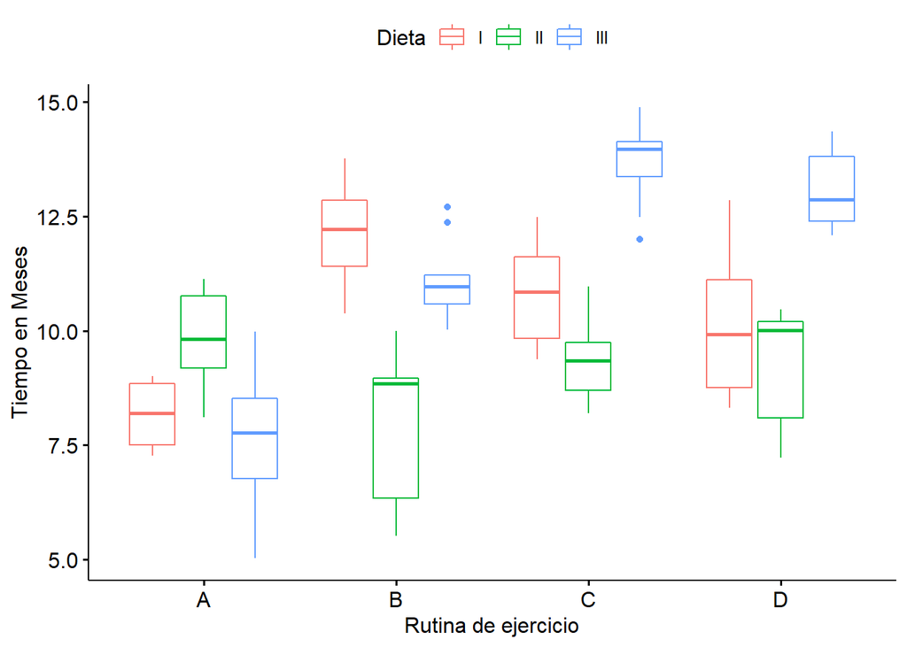

```r
#Boxplots de las medias
ggboxplot(Datos, x = "Ejercicios", y = "Tiempo_Caminar",
                color = "Dieta",ylab = "Tiempo en Meses", xlab = "Rutina de ejercicio")
```

Ahora para hacer el anova que involucre los dos factores y su interacción :

```r
Anova<-aov(Tiempo~Ejercicios+Dieta+Ejercicios*Dieta)
## Revisan los resultados
summary(Anova)
```

```
##                   Df Sum Sq Mean Sq F value   Pr(>F)
## Ejercicios         3  132.2   44.08   30.00 3.48e-14 ***
## Dieta              2  102.0   51.02   34.71 2.28e-12 ***
## Ejercicios:Dieta   6  190.1   31.69   21.56  < 2e-16 ***
## Residuals        108  158.7    1.47
## ---
## Signif. codes:  0 '***' 0.001 '**' 0.01 '*' 0.05 '.' 0.1 ' ' 1
```